# Project1

## Part 2

```
## # A tibble: 5 × 2
##   continent distinct_points
##   <chr>               <int>
## 1 Africa                  1
## 2 Americas                1
## 3 Asia                    1
## 4 Blend                   1
## 5 Oceania                 1
```

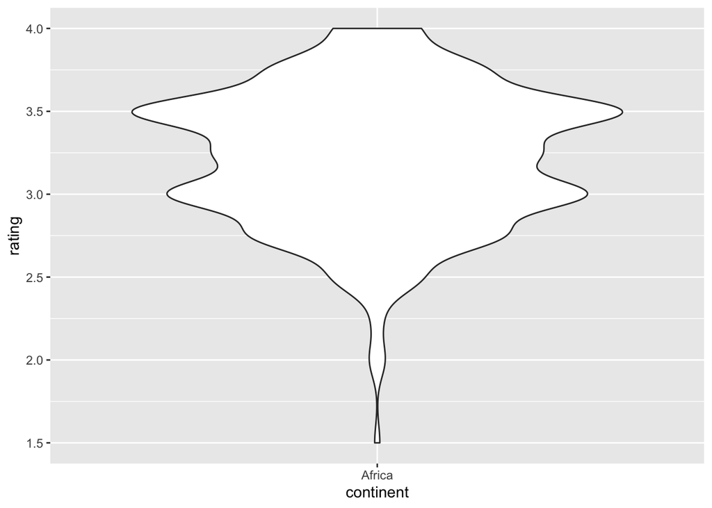

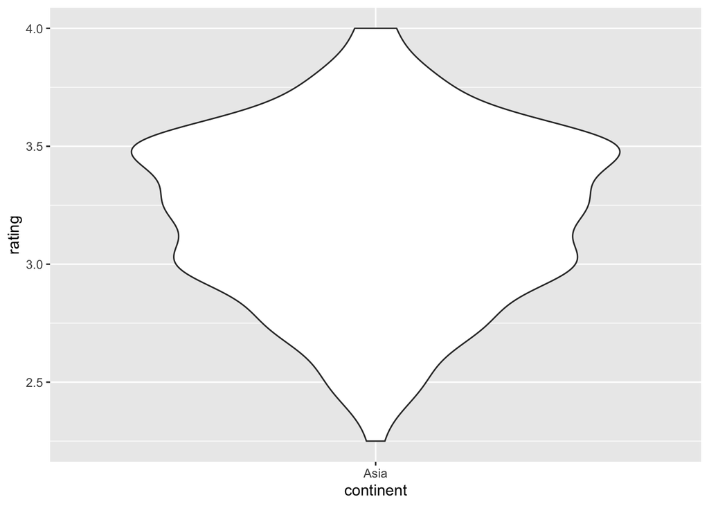

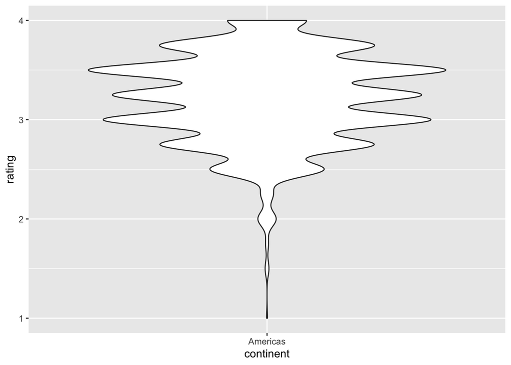

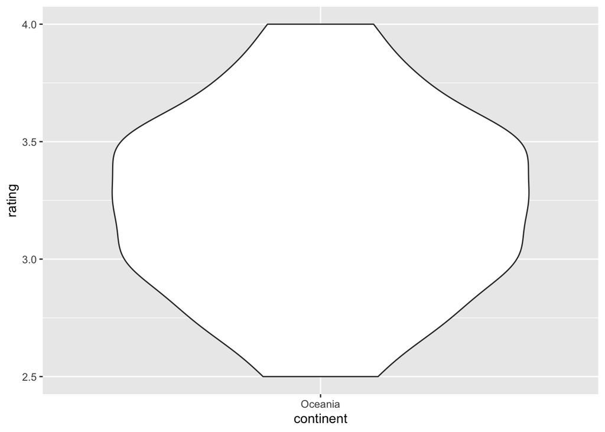

##Part 3

```r
library(tidyverse)
library(here)
chocolate <- readRDS(here("data", "chocolate.RDS"))
#add ingredient columns
chocolate <- mutate(chocolate, beans = case_when(grepl("B", ingredients) ~ 1, .default = 0))
chocolate <- mutate(chocolate, sugar = case_when(grepl("S", ingredients) ~ 1, .default = 0))
chocolate <- mutate(chocolate, cocoa_butter = case_when(grepl("C", ingredients) ~ 1, .default = 0))
chocolate <- mutate(chocolate, vanilla = case_when(grepl("V", ingredients) ~ 1, .default = 0))
chocolate <- mutate(chocolate, lecithin = case_when(grepl("L", ingredients) ~ 1, .default = 0))
chocolate <- mutate(chocolate, salt = case_when(grepl("Sa", ingredients) ~ 1, .default = 0))
#add characteristic columns
chocolate <- mutate(chocolate, char_cocoa = case_when(grepl("cocoa", most_memorable_characteristics) ~ 1, .default = 0))
chocolate <- mutate(chocolate, char_sweet = case_when(grepl("sweet", most_memorable_characteristics) ~ 1, .default = 0))
chocolate <- mutate(chocolate, char_nutty = case_when(grepl("nutty", most_memorable_characteristics) ~ 1, .default = 0))
chocolate <- mutate(chocolate, char_creamy = case_when(grepl("creamy", most_memorable_characteristics) ~ 1, .default = 0))
chocolate <- mutate(chocolate, char_roasty = case_when(grepl("roasty", most_memorable_characteristics) ~ 1, .default = 0))
chocolate <- mutate(chocolate, char_earthy = case_when(grepl("earthy", most_memorable_characteristics) ~ 1, .default = 0))
#group by year and calculate means
chocolate <- subset(chocolate, select=-c(ref, company_manufacturer, company_location, country_of_bean_origin, specific_bean_origin_or_bar_name, cocoa_percent, ingredients, most_memorable_characteristics, rating ))
chocolate <- group_by(chocolate, review_date)
chocolate <- summarize(chocolate,
              beans = mean(beans, na.rm = TRUE),
              sugar = mean(sugar, na.rm = TRUE),
              cocoa_butter = mean(cocoa_butter, na.rm = TRUE),
              vanilla = mean(vanilla, na.rm = TRUE),
              lecithin = mean(lecithin, na.rm = TRUE),
              salt = mean(salt, na.rm = TRUE),
              char_cocoa = mean(char_cocoa, na.rm = TRUE),
              char_sweet = mean(char_sweet, na.rm = TRUE),
              char_nutty = mean(char_nutty, na.rm = TRUE),
              char_creamy = mean(char_creamy, na.rm = TRUE),
              char_roasty = mean(char_roasty, na.rm = TRUE),
              char_earthy = mean(char_earthy, na.rm = TRUE))
chocolate_long <- chocolate %>% pivot_longer(-review_date, names_to = "features", values_to = "mean_score")
print(chocolate_long, n=192)
```

```
## # A tibble: 192 × 3
##     review_date features     mean_score
##           <dbl> <chr>             <dbl>
##   1        2006 beans           0.968
##   2        2006 sugar           0.968
##   3        2006 cocoa_butter    0.903
##   4        2006 vanilla         0.694
##   5        2006 lecithin        0.694
##   6        2006 salt            0
##   7        2006 char_cocoa      0.210
##   8        2006 char_sweet      0.161
##   9        2006 char_nutty      0.0323
##  10        2006 char_creamy     0.242
##  11        2006 char_roasty     0.0484
##  12        2006 char_earthy     0.0645
```

[output cut: 180 more lines]

Long dataset of mean scores for each ingredient and main characteristic by review year

##. Part 4

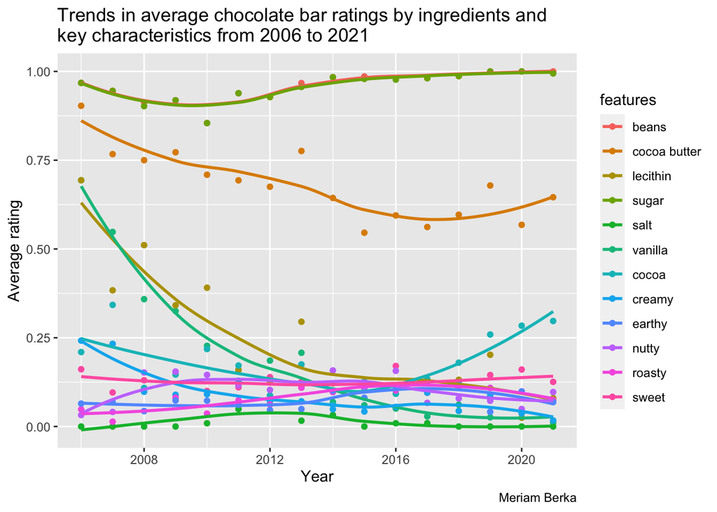

```r
library(tidyverse)
library(here)
library(ggplot2)

#rename flavors so they're more descriptive
chocolate_long <- mutate(chocolate_long, features = str_remove(features, "char_"))
chocolate_long <- mutate(chocolate_long, features = if_else(features == "cocoa_butter", "cocoa butter", features))
#reorder features, ingredients then flavours"
chocolate_long <- chocolate_long %>% mutate(features = fct_relevel(features, c("cocoa butter", "lecithin", "sugar", "salt", "vanilla"), after=1))
#create plot
chocolate_long %>% ggplot(aes(review_date, mean_score)) + geom_point(aes(color = features)) + geom_smooth(aes(group=features, color = features), se = FALSE) + labs(title = "Trends in average chocolate bar ratings by ingredients and\nkey characteristics from 2006 to 2021", caption = "Meriam Berka") + xlab("Year") + ylab("Average rating") + scale_x_continuous(breaks = c(2008, 2012, 2016, 2020), minor_breaks = c(2006, 2010, 2014, 2018, 2022)) + theme_gray()
```

##. Part 5

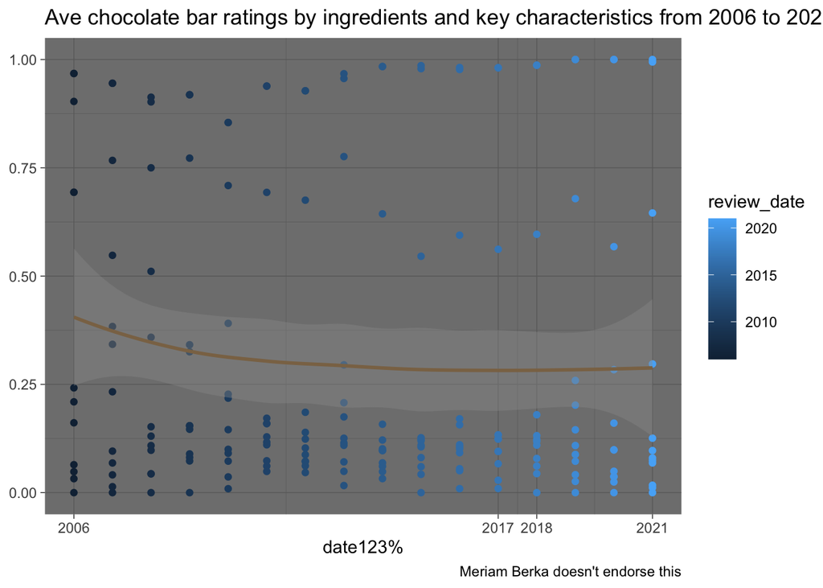

```r
library(tidyverse)
library(here)
library(ggplot2)

chocolate_long %>% ggplot(aes(review_date, mean_score)) + geom_point(aes(color = review_date)) + geom_smooth(color = "burlywood4") + labs(title = "Ave chocolate bar ratings by ingredients and key characteristics from 2006 to 2021", caption = "Meriam Berka doesn't endorse this") + xlab("date123%") + ylab(NULL) + scale_x_continuous(breaks = c(2006, 2017, 2018, 2021)) + theme_dark()
```

- Instead of colors being used to make trends in features clear it’s highlighting years, which are already obvious based on the x-axis.
- Colors are inconsistent, compared to the original plot where the same colors were used for points and trends lines, and are low contrast.
- Overall trend line doesn’t communicate anything meaningful, it’s an average of all points over the years.
- Title is not wrapped to the plot.
- Y-label is missing, x-label is uninformative, and x-axis breaks are inconsistent making it very difficult to know what’s even being plotted.
- The plot doesn’t actually show what the title says it should, since the features are not identified in any way (ex. by color, or shape of points) trends can not be discerned.

##. Part 6

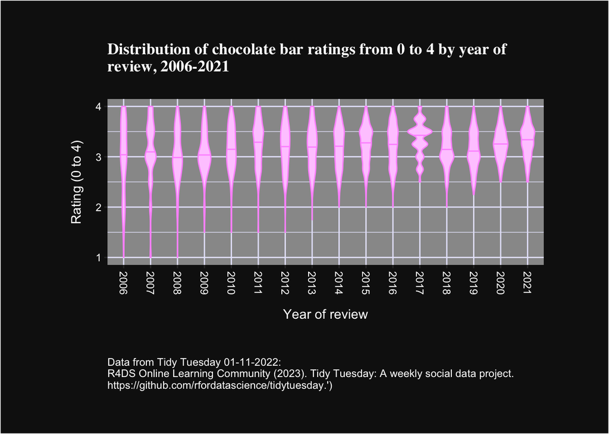

```r
library(tidyverse)
library(here)
library(ggplot2)
chocolate <- readRDS(here("data", "chocolate.RDS"))

chocolate %>%
    ggplot(aes(x = as.factor(review_date), y = rating)) + geom_violin(draw_quantiles = c(0.5), color = "#FF99FF", fill = "#FFCCFF")  + ggtitle("Distribution of chocolate bar ratings from 0 to 4 by year of\nreview, 2006-2021") + labs(caption = "Data from Tidy Tuesday 01-11-2022:\nR4DS Online Learning Community (2023). Tidy Tuesday: A weekly social data project.\nhttps://github.com/rfordatascience/tidytuesday.')") + xlab("Year of review") + ylab("Rating (0 to 4)") + theme(plot.title = element_text(margin = margin( 0.01, 0, 20, 0), family = "serif", face = "bold"), axis.text.x = element_text(angle = 270, vjust = 0.5, hjust=1, color = "white"), axis.text.y = element_text(color = "white"), axis.title.x = element_text(margin = margin(12, 0, 25, 0)), axis.title.y = element_text(margin = margin(10, 10, 10, 5)), plot.caption = element_text(hjust = 0, color = "white"), panel.grid.major = element_line(size = 0.5, linetype = 'solid', colour = "lavender"), panel.grid.minor = element_line(size = 0.25, linetype = 'solid', colour = "lavender"), text = element_text(color = "white"), plot.background = element_rect(fill = "gray7"), panel.background = element_rect(fill="gray60"), plot.margin = unit(c(0.5, 0.75, 0.5, 0.75), "inches"))
```

- Added an informative title so it’s clear what is actually being represented by this graph and to aid in interpretation.
- Added y-axis label and x-axis labels and rotated x-axis labels so they’re less cluttered and easier to read.
- Added caption with data citation to properly attribute the data used.
- Added line at median of each plot to make it easier to visually compare average scores across years.
- Changed line to lavender, text to white, background to dark gray, and panel to light grey to increase visual interest while maintaining color contrast.
- Increased text spacing, including adding a gap between axis labels and axes and title and plot. The caption was also moved to the bottom of the page since it’s extra information and not a part of the actual plot.
- Changed title font to make it cuter!